# La aleatoriedad y los dados de 6

Angel Berlanas Vicente

2022-03-20

## La Aleatoriedad

Dentro de un sistema determinista cómo es el ordenador, obtener valores aleatorios ha sido desde los inicios de la informática un campo que ha tenido muchísimo desarrollo. Si sabes cual es el algoritmo (método), que emplea el ordenador para obtener un número, siempre obtendrá el mismo.

Algunos de los factores que se aplican para dar *variabilidad* a la obtención de números dentro de ordenadores son:

- Milisegundo en el que se ejecuta el programa.
- Datos almacenados en la RAM de determinados sectores.
- Volumen de datos escritos en el disco.
- Semillas aleatorias para la generación de esos números.

En general, el ordenador hace lo posible por generar **entropía** (Aaronson 2016) y ofrecer resultados verdaderamente aleatorios al usuario/programa.

## Dados de 6

Soy un aficionado a los juegos de mesa y debido a la imposibilidad (relacionada con la pandemia o con la distáncia), de poder quedar a realizar partidas, existen determinados programas que permiten la implementación online de los diferentes componentes de un juego de mesa:

- El tablero.
- Las fichas.
- Las hojas de ayuda.
- Los marcadores de puntuación.
- Los dados.

Además, para facilitar las partidas, suministran una serie de botones y mecanismos para realizar tiradas de dados.

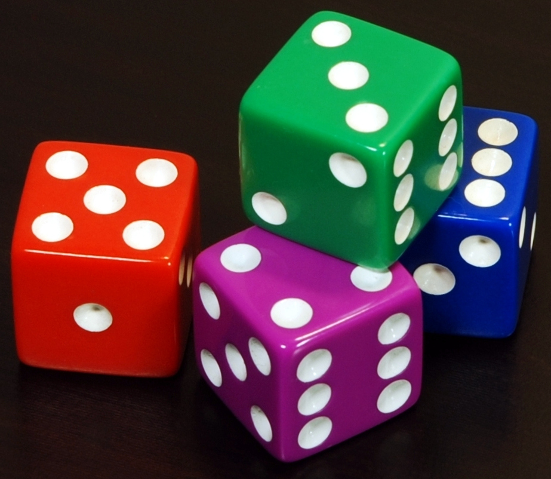

Estos sistemas de lanzamiento de dados, dentro de la comunidad de jugadores son víctima de una cierta animadversión, ya que no se fían de que los resultados que salen son **realmente** aleatorios.

A continuación se muestra una pequeña demostración, donde se plantea que lo que ocurre es que el jugador aplica cierto sesgo al considerar tan sólo los resultados que le son especialmente beneficiosos o perjudiciales.

Simularemos varios escenarios.

## Escenario 1: Pocas tiradas

```r
set.seed(5)
# Generamos 20 tiradas aleatorias con los resultados de un dado de 6 caras (1d6)
escenario_corto<-sample(c(1:6), 20, replace = TRUE)
```

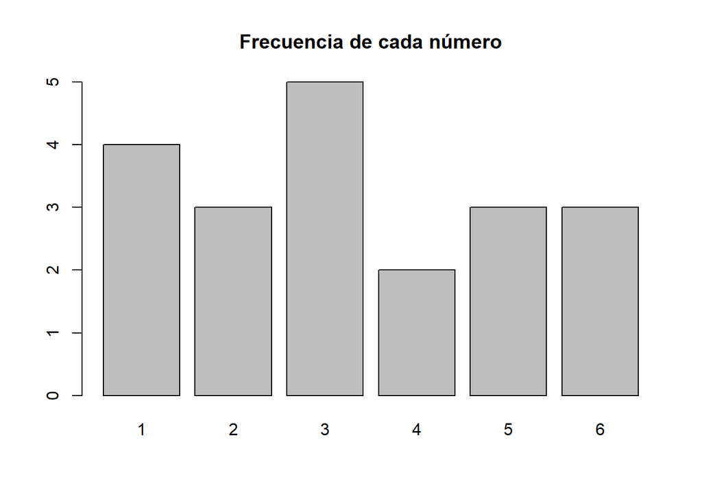

```r
barplot(table(escenario_corto), main="Frecuencia de cada número")
```

Cómo se aprecia en la imágen, es posible que haya un porcentaje de tiradas que han obtenido el mismo resultado, pero eso es debido a que *tan sólo* estamos realizando 20 lanzamientos. Con lo que es muy posible que un determinado resultado aparezca *pocas veces* en relación con *otro* resultado.

## Escenario 2 : 1K tiradas

```r
set.seed(5)
# Generamos 10000 tiradas aleatorias con los resultados de un dado de 6 caras (1d6)
escenario_medio<-sample(c(1:6), 1000, replace = TRUE)
```

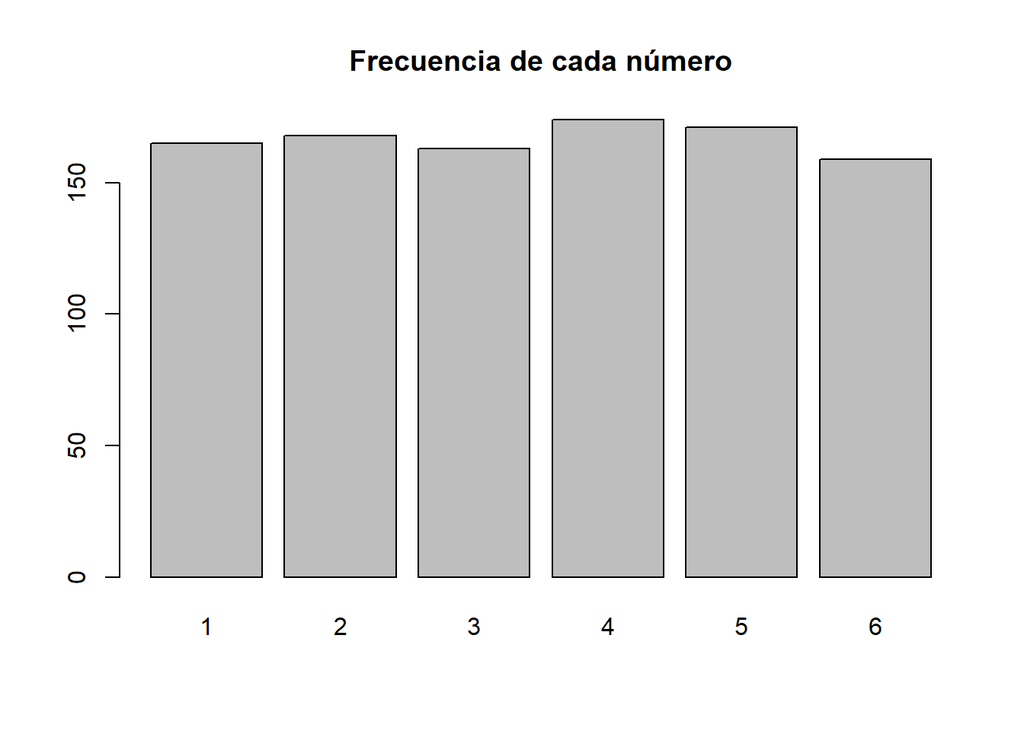

```r
barplot(table(escenario_medio), main="Frecuencia de cada número")
```

Ahora podemos ver como aunque sigue habiendo diferencias entre los diferentes posibles resultados, a medida que aumentamos el número de tiradas realizadas, comprobamos que el número de veces que aparece cada uno de los números difiere menos del resto de posibles resultados.

## Escenario 3 : 1M tiradas

```r
set.seed(5)
# Generamos 10000 tiradas aleatorias con los resultados de un dado de 6 caras (1d6)
escenario_largo<-sample(c(1:6), 1000000, replace = TRUE)
```

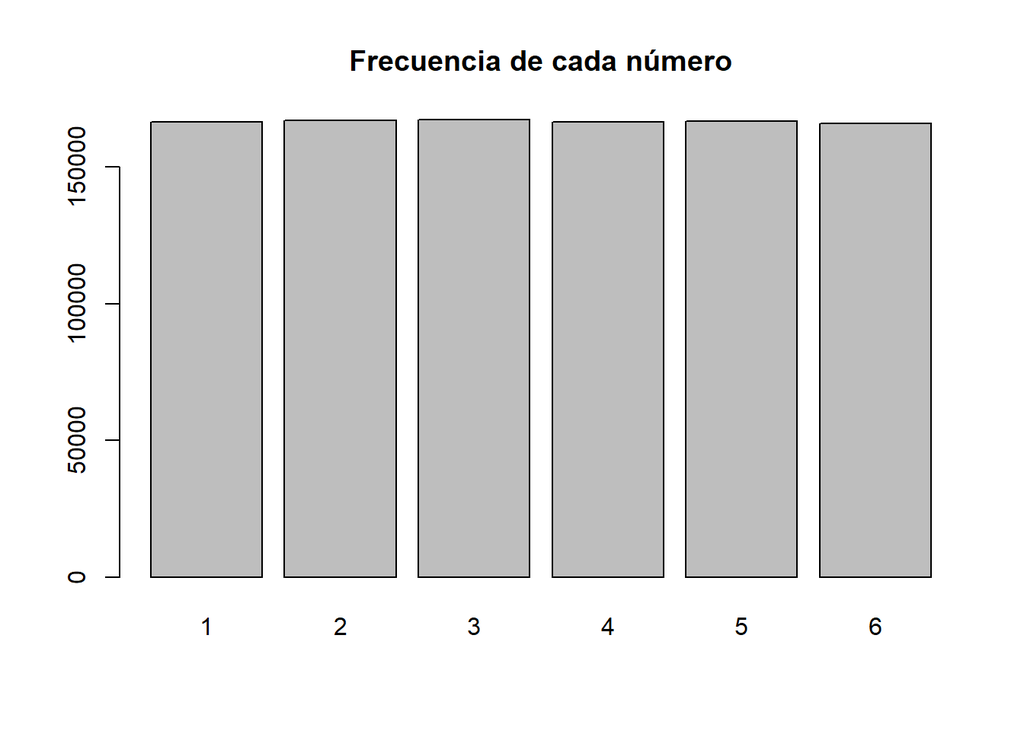

```r
barplot(table(escenario_largo), main="Frecuencia de cada número")
```

En este caso, la variación es muy pequeña (de hecho, tan pequeña que no se aprecia en la tabla), apreciando así que realmente existe la aleatoriedad en los mecanismos, pero que tan sólo se aprecia si se realizan muchas tiradas, si cogemos una muestra pequeña puede dar lugar a pensar que hay resultados que se obtienen más que otros.

Aaronson, Scott. 2016. “The Quest for Randomness.” *The Best Writing on Mathematics 2015* 14: 69.